# Biostat M280 Homework 1 Solution Sketch

```julia
versioninfo()
```

```
Julia Version 0.5.1
Commit 6445c82 (2017-03-05 13:25 UTC)
Platform Info:
  OS: macOS (x86_64-apple-darwin13.4.0)
  CPU: Intel(R) Core(TM) i7-6920HQ CPU @ 2.90GHz
  WORD_SIZE: 64
  BLAS: libopenblas (USE64BITINT DYNAMIC_ARCH NO_AFFINITY Haswell)
  LAPACK: libopenblas64_
  LIBM: libopenlibm
  LLVM: libLLVM-3.7.1 (ORCJIT, broadwell)
```

## Q2

Let's check whether floating-point numbers obey certain algebraic rules.

- Associative rule for addition says `(x + y) + z == x + (y + z)`. Floating-point numbers do not necessarily follow association rule.

```julia
x = 0.1; y = 0.1; z = 1.0
(x + y) + z == x + (y + z) # association rule violated
```

```
false
```

```julia
@show (x + y) + z
@show x + (y + z)
```

```
(x + y) + z = 1.2
x + (y + z) = 1.2000000000000002
```

```
1.2000000000000002
```

```julia
@show bits(x)  # rounding from 1001 to 1010 in RoundNearest mode
@show bits(y)  # rounding from 1001 to 1010 in RoundNearest mode
```

```
bits(x) = "0011111110111001100110011001100110011001100110011001100110011010"
bits(y) = "0011111110111001100110011001100110011001100110011001100110011010"
```

```
"0011111110111001100110011001100110011001100110011001100110011010"
```

```julia
@show bits(x + y)
@show bits(z);
```

```
bits(x + y) = "0011111111001001100110011001100110011001100110011001100110011010"
bits(z) = "0011111111110000000000000000000000000000000000000000000000000000"
```

```julia
@show bits(x)
@show bits(y + z);
```

```
bits(x) = "0011111110111001100110011001100110011001100110011001100110011010"
bits(y + z) = "0011111111110001100110011001100110011001100110011001100110011010"
```

- Floating-point numbers do not necessarily follow association rule for multiplication.

```julia
x = 0.1; y = 0.2; z = 0.3
(x * y) * z == x * (y * z)
```

```
false
```

```julia
@show (x * y) * z
@show x * (y * z)
```

```
(x * y) * z = 0.006000000000000001
x * (y * z) = 0.006
```

```
0.006
```

- Distributive rule says `a * (x + y) == a * x + a * y`. Floating-point numbers do not necessarily follow the distributive rule.

```julia
x = 0.1; y = 0.2; a = 5.0
a * (x + y) == a * x + a * y
```

```
false
```

```julia
@show a * (x + y)
@show a * x + a * y
```

```
a * (x + y) = 1.5000000000000002
a * x + a * y = 1.5
```

```
1.5
```

```julia
@show bits(x)
@show bits(y)
@show bits(a);
```

```
bits(x) = "0011111110111001100110011001100110011001100110011001100110011010"
bits(y) = "0011111111001001100110011001100110011001100110011001100110011010"
bits(a) = "0100000000010100000000000000000000000000000000000000000000000000"
```

```julia
@show bits(x + y)
@show bits(a * (x + y));
```

```
bits(x + y) = "0011111111010011001100110011001100110011001100110011001100110100"
bits(a * (x + y)) = "0011111111111000000000000000000000000000000000000000000000000001"
```

```julia
@show bits(a * x)
@show bits(a * y)
@show bits(a * x + a * y);
```

```
bits(a * x) = "0011111111100000000000000000000000000000000000000000000000000000"
bits(a * y) = "0011111111110000000000000000000000000000000000000000000000000000"
bits(a * x + a * y) = "0011111111111000000000000000000000000000000000000000000000000000"
```

- Is that true `0 * x == 0` for all floating-point number `x`?

```julia
0.0 * Inf
```

```
NaN
```

- Is `x / a == x * (1 / a)` always true? Try with `x = 3.0`, `a = 5.0` and explain what you find.

```julia
x = 3.0; a = 5.0
x / a == x * (1 / a)
```

```
false
```

```julia
@show x / a
@show x * (1 / a)
```

```
x / a = 0.6
x * (1 / a) = 0.6000000000000001
```

```
0.6000000000000001
```

```julia
@show bits(x / a)
@show bits(x * (1 / a))
```

```
bits(x / a) = "0011111111100011001100110011001100110011001100110011001100110011"
bits(x * (1 / a)) = "0011111111100011001100110011001100110011001100110011001100110100"
```

```
"0011111111100011001100110011001100110011001100110011001100110100"
```

## Q3

```julia
function g(k)
    for i = 1:10
        k = 5k - 1
    end
    k
end
```

```
g (generic function with 1 method)
```

Computer integer arithmetic obeys the usual associative and distributive rules. LLVM is able to optimize, according to the associative rule, the loop

```
for i = 1:10
    k = 5k - 1
end
```

to

[output not shown]

```julia
code_llvm(g, (Int,))
```

```
define i64 @julia_g_71651(i64) #0 {
top:
  %1 = mul i64 %0, 9765625
  %2 = add i64 %1, -2441406
  ret i64 %2
}
```

Floating-point numbers do not necessarily obey the associative rule. This prevents LLVM from the simplification.

```julia
code_llvm(g, (Float64,))
```

```
define double @julia_g_71654(double) #0 {
top:
  %1 = fmul double %0, 5.000000e+00
  %2 = fadd double %1, -1.000000e+00
  %3 = fmul double %2, 5.000000e+00
  %4 = fadd double %3, -1.000000e+00
  %5 = fmul double %4, 5.000000e+00
  %6 = fadd double %5, -1.000000e+00
  %7 = fmul double %6, 5.000000e+00
  %8 = fadd double %7, -1.000000e+00
  %9 = fmul double %8, 5.000000e+00
  %10 = fadd double %9, -1.000000e+00
  %11 = fmul double %10, 5.000000e+00
  %12 = fadd double %11, -1.000000e+00
  %13 = fmul double %12, 5.000000e+00
  %14 = fadd double %13, -1.000000e+00
  %15 = fmul double %14, 5.000000e+00
  %16 = fadd double %15, -1.000000e+00
  %17 = fmul double %16, 5.000000e+00
  %18 = fadd double %17, -1.000000e+00
  %19 = fmul double %18, 5.000000e+00
  %20 = fadd double %19, -1.000000e+00
  ret double %20
}
```

The [`@fastmath` macro](https://docs.julialang.org/en/stable/manual/performance-tips/?highlight=fastmath#performance-annotations) enables compiler optimization by assuming the associative law.

```julia
function g_fastmath(k)
    @fastmath for i = 1:10
        k = 5k - 1
    end
    k
end

code_llvm(g_fastmath, (Float64,))
```

```
define double @julia_g_fastmath_71656(double) #0 {
top:
  %1 = fmul fast double %0, 9.765625e+06
  %2 = fadd fast double %1, -2.441406e+06
  ret double %2
}
```

## Q4

Create the vector `x = (0.988, 0.989, 0.990, ..., 1.010, 1.011, 1.012)`.

1. Plot the polynomial `y = x^7 - 7x^6 + 21x^5 - 35x^4 + 35x^3 - 21x^2 + 7x - 1` at points `x`.
2. Plot the polynomial `y = (x - 1)^7` at points `x`.
3. Explain what you found.

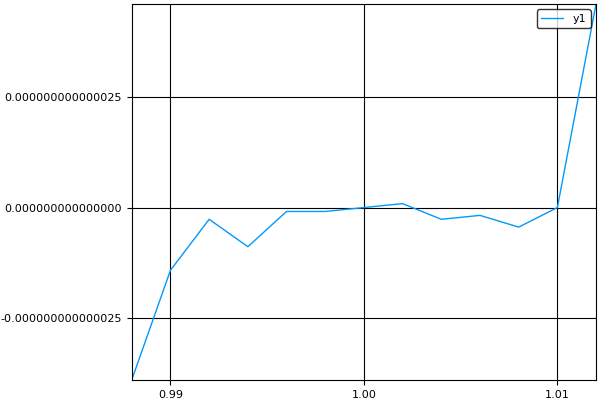

```julia
using Plots
pyplot()
#plotly()
#gr()

x = 0.988:0.002:1.012
y1 = x.^7 - 7x.^6 + 21x.^5 - 35x.^4 + 35x.^3 - 21x.^2 + 7x - 1
plot(x, y1)
```

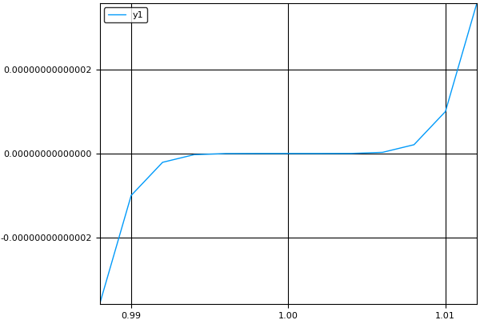

```julia
y2 = (x - 1).^7
plot(x, y2)
```

## Q5

Read in the matrix in the file `longley.txt` on the macroeconomic data from 1947 to 1962. The columns are Employment, Prices, GNP, Jobless, Military, PopSize and Year. Plot the pairwise scatter plot between these variables. What do you observe?

```julia
longley = readdlm("longley.txt")
```

```
16×7 Array{Float64,2}:
 60323.0   83.0  234289.0  2356.0  1590.0  107608.0  1947.0
 61122.0   88.5  259426.0  2325.0  1456.0  108632.0  1948.0
 60171.0   88.2  258054.0  3682.0  1616.0  109773.0  1949.0
 61187.0   89.5  284599.0  3351.0  1650.0  110929.0  1950.0
 63221.0   96.2  328975.0  2099.0  3099.0  112075.0  1951.0
 63639.0   98.1  346999.0  1932.0  3594.0  113270.0  1952.0
 64989.0   99.0  365385.0  1870.0  3547.0  115094.0  1953.0
 63761.0  100.0  363112.0  3578.0  3350.0  116219.0  1954.0
 66019.0  101.2  397469.0  2904.0  3048.0  117388.0  1955.0
 67857.0  104.6  419180.0  2822.0  2857.0  118734.0  1956.0
 68169.0  108.4  442769.0  2936.0  2798.0  120445.0  1957.0
 66513.0  110.8  444546.0  4681.0  2637.0  121950.0  1958.0
 68655.0  112.6  482704.0  3813.0  2552.0  123366.0  1959.0
 69564.0  114.2  502601.0  3931.0  2514.0  125368.0  1960.0
 69331.0  115.7  518173.0  4806.0  2572.0  127852.0  1961.0
 70551.0  116.9  554894.0  4007.0  2827.0  130081.0  1962.0
```

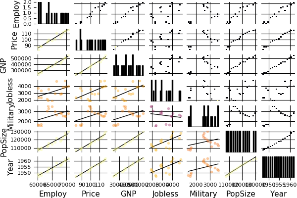

```julia
using StatPlots
pyplot()
#plotly()
#gr()

corrplot(longley, label = ["Employ" "Price" "GNP" "Jobless" "Military" "PopSize" "Year"])
```

```julia
cor(longley)
```

[output not shown]

```
7×7 Array{Float64,2}:
 1.0       0.970899  0.983552   0.502498   0.457307  0.960391  0.971329
 0.970899  1.0       0.991589   0.620633   0.464744  0.979163  0.991149
 0.983552  0.991589  1.0        0.604261   0.446437  0.99109   0.995273
 0.502498  0.620633  0.604261   1.0       -0.177421  0.686552  0.668257
 0.457307  0.464744  0.446437  -0.177421   1.0       0.364416  0.417245
 0.960391  0.979163  0.99109    0.686552   0.364416  1.0       0.993953
 0.971329  0.991149  0.995273   0.668257   0.417245  0.993953  1.0
```

We observe that variables Employment, Price, GNP, PopSize, Year are higly correlated.

## Q6

Let's write a function for generating the Hilbert matrix using looping (`h1`), comprehension (`h2`) and vectorized code (`h3`).

```julia
# looping
function h1(n)
    H = zeros(n, n)
    for j in 1:n, i in 1:n
        H[i, j] = 1 / (i + j - 1)
    end
    H
end

h1(5)
```

```
5×5 Array{Float64,2}:
 1.0       0.5       0.333333  0.25      0.2
 0.5       0.333333  0.25      0.2       0.166667
 0.333333  0.25      0.2       0.166667  0.142857
 0.25      0.2       0.166667  0.142857  0.125
 0.2       0.166667  0.142857  0.125     0.111111
```

```julia
# comprehension
function h2(n)
    H = [1 / (i + j - 1) for i in 1:n, j in 1:n]
end

h2(5)
```

```
5×5 Array{Float64,2}:
 1.0       0.5       0.333333  0.25      0.2
 0.5       0.333333  0.25      0.2       0.166667
 0.333333  0.25      0.2       0.166667  0.142857
 0.25      0.2       0.166667  0.142857  0.125
 0.2       0.166667  0.142857  0.125     0.111111
```

```julia
# vecterized code
function h3(n)
    H = 1 ./ (repmat((1:n)', n, 1) + repmat((1:n), 1, n) - 1)
end

h3(5)
```

```
5×5 Array{Float64,2}:
 1.0       0.5       0.333333  0.25      0.2
 0.5       0.333333  0.25      0.2       0.166667
 0.333333  0.25      0.2       0.166667  0.142857
 0.25      0.2       0.166667  0.142857  0.125
 0.2       0.166667  0.142857  0.125     0.111111
```

We use BenchmarkTool.jl to benchmark functions at `n = 1000`.

```julia
using BenchmarkTools

n = 1000
@benchmark h1(n)
```

```
BenchmarkTools.Trial:
  memory estimate:  7.63 MiB
  allocs estimate:  2
  --------------
  minimum time:     2.763 ms (0.00% GC)
  median time:      3.131 ms (0.00% GC)
  mean time:        4.093 ms (24.96% GC)
  maximum time:     7.261 ms (44.33% GC)
  --------------
  samples:          1216
  evals/sample:     1
```

```julia
@benchmark h2(n)
```

```
BenchmarkTools.Trial:
  memory estimate:  7.63 MiB
  allocs estimate:  2
  --------------
  minimum time:     2.884 ms (0.00% GC)
  median time:      3.140 ms (0.00% GC)
  mean time:        3.627 ms (15.59% GC)
  maximum time:     7.125 ms (41.42% GC)
  --------------
  samples:          1376
  evals/sample:     1
```

```julia
@benchmark h3(n)
```

```
BenchmarkTools.Trial:
  memory estimate:  38.31 MiB
  allocs estimate:  5013
  --------------
  minimum time:     14.631 ms (5.38% GC)
  median time:      17.564 ms (25.15% GC)
  mean time:        17.575 ms (25.98% GC)
  maximum time:     106.705 ms (86.49% GC)
  --------------
  samples:          284
  evals/sample:     1
```

We see looping and comprehension is much more efficient than vectorized code.

Note because Julia stores matrix in column-major, `ji` looping is more efficient than `ij` looping.

```julia
# ij looping: inefficient
function h4(n)
    H = zeros(n, n)
    for i in 1:n, j in 1:n
        H[i, j] = 1 / (i + j - 1)
    end
    H
end

@benchmark h4(n)
```

```
BenchmarkTools.Trial:
  memory estimate:  7.63 MiB
  allocs estimate:  2
  --------------
  minimum time:     3.456 ms (0.00% GC)
  median time:      4.569 ms (0.00% GC)
  mean time:        5.604 ms (18.80% GC)
  maximum time:     14.623 ms (43.45% GC)
  --------------
  samples:          888
  evals/sample:     1
```

```julia
function h5(n)
    v = collect(1:n)
    return 1 ./ (v .+ v' - 1)
end

@benchmark h5(n)
```

```
BenchmarkTools.Trial:
  memory estimate:  22.90 MiB
  allocs estimate:  23
  --------------
  minimum time:     7.539 ms (28.60% GC)
  median time:      9.948 ms (33.18% GC)
  mean time:        11.294 ms (31.32% GC)
  maximum time:     20.982 ms (29.91% GC)
  --------------
  samples:          441
  evals/sample:     1
```

```julia
H = h1(15)
for rmode in [RoundNearest RoundUp RoundDown]
    setrounding(Float64, rmode) do
        @show inv(H)[1,1]
    end
end
```

```
(inv(H))[1,1] = 158.1023247167468
(inv(H))[1,1] = 151.9317292883061
(inv(H))[1,1] = 147.25887333601713
```

We see rounding does have an effect on numerical calculation. More dramatic effects occur for matrix `H[i, j] = 1 / (i + j + 1)`.

```julia
n = 15
H = [1 / (i + j + 1) for i = 1:n, j = 1:n]
for rmode in [RoundNearest RoundUp RoundDown]
    setrounding(Float64, rmode) do
        @show inv(H)[1,1]
    end
end
```

```
(inv(H))[1,1] = -138784.4138031006
(inv(H))[1,1] = -175965.83673095703
(inv(H))[1,1] = 315906.84297180176
```